# Adding images to phylogenies

Author

Jeet Sukumaran

## 1 Setting up the environment

**NoteRequired packages**

`GLMakie` and `PhyloMakie.jl` need to be installed in the active environment. If this has not already been done, run:

```julia
using Pkg

Pkg.add("GLMakie")
Pkg.add("PhyloMakie")
```

Load the packages with:

```julia
using GLMakie
using PhyloMakie
```

## 2 Generating the phylogeny

```julia
phylogeny_newick = "(red,(orange,(yellow,(green,(blue,(indigo,violet))))));"
```

```
"(red,(orange,(yellow,(green,(blue,(indigo,violet))))));"
```

```julia
phylogeny = parsephylogeny(NewickFormat(), phylogeny_newick)
```

```
LineageNetwork(13 nodes, 12 edges, 7 leaves, 0 hybrid nodes, rooted)
```

## 3 Plotting the phylogeny

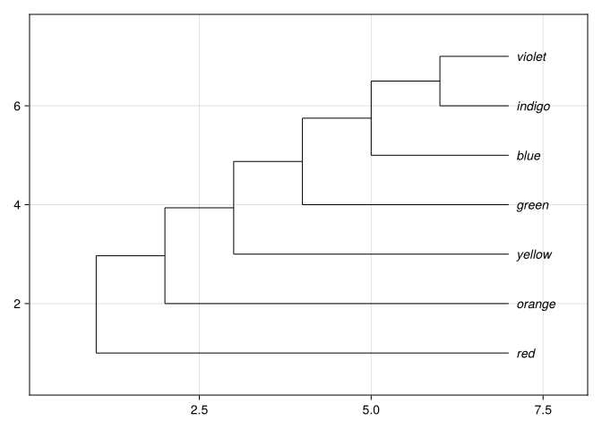

Figure 1: The ladderized phylogeny before leaf images are added.

```julia
plot_result = plot(
    phylogeny;
    useedgelength = false,
    leafoffset = 0.12,
)
```

## 4 Adding images to the phylogeny

### 4.1 Adding images from URLs

In this example, we use color patches sources from Wikimedia Commons

| Leaf | Wikimedia Commons source | Creator | Reuse status |
| --- | --- | --- | --- |
| `red` | Red-ff0000.png | Vcvfou698069 | Public domain |
| `orange` | [Solid orange.png](https://commons.wikimedia.org/wiki/File:Solid_orange.png) | Rocket000 | Public domain |
| `yellow` | [Solid yellow.png](https://commons.wikimedia.org/wiki/File:Solid_yellow.png) | Rocket000 | Public domain |
| `green` | [Solid green.png](https://commons.wikimedia.org/wiki/File:Solid_green.png) | Rocket000 | Public domain |
| `blue` | [Solid blue.png](https://commons.wikimedia.org/wiki/File:Solid_blue.png) | Rocket000 | Public domain |
| `indigo` | [Solid indigo.svg](https://commons.wikimedia.org/wiki/File:Solid_indigo.svg) | Fringio | CC0 1.0 |
| `violet` | [Solid violet.svg](https://commons.wikimedia.org/wiki/File:Solid_violet.svg) | Sangjinhwa | Public domain |

We create a `Dict` (dictionary) value that maps the leaves, as addressed by their labels, to the corresponding image URLs: below gives us direct PNG URLs that PhyloMakie can download

```julia
image_urls = Dict(
    "red" => "https://upload.wikimedia.org/wikipedia/commons/7/7f/Red-ff0000.png",
    "orange" => "https://upload.wikimedia.org/wikipedia/commons/a/a8/Solid_orange.png",
    "yellow" => "https://upload.wikimedia.org/wikipedia/commons/6/6d/Solid_yellow.png",
    "green" => "https://upload.wikimedia.org/wikipedia/commons/c/c7/Solid_green.png",
    "blue" => "https://upload.wikimedia.org/wikipedia/commons/e/e5/Solid_blue.png",
    "indigo" => "https://thumb.wikimedia.org/wikipedia/commons/thumb/5/5f/Solid_indigo.svg/960px-Solid_indigo.svg.png",
    "violet" => "https://upload.wikimedia.org/wikipedia/commons/thumb/2/24/Solid_violet.svg/960px-Solid_violet.svg.png",
)
```

```
Dict{String, String} with 7 entries:
  "orange" => "https://upload.wikimedia.org/wikipedia/commons/a/a8/Solid_orange…
  "red"    => "https://upload.wikimedia.org/wikipedia/commons/7/7f/Red-ff0000.p…
  "indigo" => "https://thumb.wikimedia.org/wikipedia/commons/thumb/5/5f/Solid_i…
  "green"  => "https://upload.wikimedia.org/wikipedia/commons/c/c7/Solid_green.…
  "violet" => "https://upload.wikimedia.org/wikipedia/commons/thumb/2/24/Solid_…
  "yellow" => "https://upload.wikimedia.org/wikipedia/commons/6/6d/Solid_yellow…
  "blue"   => "https://upload.wikimedia.org/wikipedia/commons/e/e5/Solid_blue.p…
```

**NoteInternet connection**

PhyloMakie downloads these images when the illustrated tree is first plotted. The plotting step therefore requires an internet connection.

## 5 Describing the image annotations

`ImageAnnotation` controls where and how large an image appears. Leaves are 1 data unit apart vertically, so an image height below 1 leaves space between adjacent images.

```julia
image_height = 0.65

leaf_images = Dict(
    label => ImageAnnotation(
        url;
        position = :right,
        height = image_height,
    ) for (label, url) in image_urls
);
```

We now have 3 objects with separate jobs:

| Object | Role |
| --- | --- |
| `phylogeny` | Stores the topology parsed from the Newick string. |
| `image_urls` | Maps each exact leaf label to a supplied image URL. |
| `leaf_images` | Adds placement and sizing instructions for each image. |

## 6 Adjusting the labels

First, keep the small `leafoffset` from the original tree plot. This lets us see why image placement and text placement need to be adjusted separately.

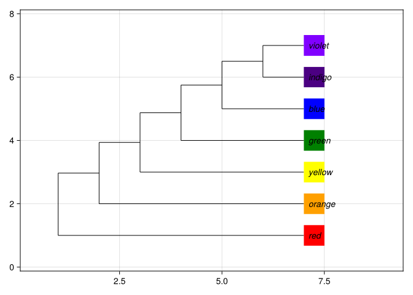

Figure 2: With the original leaf-label offset, the labels begin inside the images.

```julia
close_labels_result = plot(
    phylogeny;
    nodeimages = leaf_images,
    useedgelength = false,
    leafoffset = 0.12,
    xlim = (0.5, 9.0),
    ylim = (0.25, 7.75),
)

close_labels_result.figure
```

Two arguments are doing different jobs:

- `position = :right` places the left edge of each image at its leaf node, so the image extends to the right of the tree.
- `leafoffset = 0.12` places each leaf label only `0.12` x-axis data units to the right of its leaf node.

The image and the label therefore occupy some of the same space. Changing `position` would move the image. To move only the text, change `leafoffset`.

Increase `leafoffset` while leaving `leaf_images` unchanged. The tree topology, image size, and image placement all remain the same.

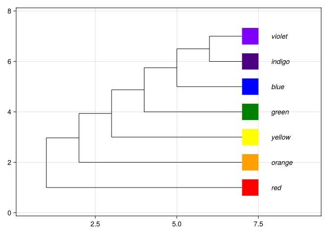

Figure 3: The ladderized phylogeny with a supplied color image mapped to each leaf.

```julia
illustrated_result = plot(
    phylogeny;
    nodeimages = leaf_images,
    useedgelength = false,
    leafoffset = 0.9,
    xlim = (0.5, 9.0),
    ylim = (0.25, 7.75),
)

illustrated_result.figure
```

The `nodeimages` argument adds the image dictionary to the live tree plot. The larger `leafoffset` moves the leaf-label text past the images, and the explicit axis limits reserve space for both the images and the labels.

Back to top